# Churn

##Load the data

```r
library(tidyverse)
library(gridExtra)
churn <- read.csv("D:/R/syesh/WA_Fn-UseC_-Telco-Customer-Churn.csv")
```

##Display the structure of the dataframe

```r
str(churn)
```

```
## 'data.frame':    7043 obs. of  21 variables:
##  $ customerID      : chr  "7590-VHVEG" "5575-GNVDE" "3668-QPYBK" "7795-CFOCW" ...
##  $ gender          : chr  "Female" "Male" "Male" "Male" ...
##  $ SeniorCitizen   : int  0 0 0 0 0 0 0 0 0 0 ...
##  $ Partner         : chr  "Yes" "No" "No" "No" ...
##  $ Dependents      : chr  "No" "No" "No" "No" ...
##  $ tenure          : int  1 34 2 45 2 8 22 10 28 62 ...
##  $ PhoneService    : chr  "No" "Yes" "Yes" "No" ...
##  $ MultipleLines   : chr  "No phone service" "No" "No" "No phone service" ...
##  $ InternetService : chr  "DSL" "DSL" "DSL" "DSL" ...
##  $ OnlineSecurity  : chr  "No" "Yes" "Yes" "Yes" ...
##  $ OnlineBackup    : chr  "Yes" "No" "Yes" "No" ...
##  $ DeviceProtection: chr  "No" "Yes" "No" "Yes" ...
##  $ TechSupport     : chr  "No" "No" "No" "Yes" ...
##  $ StreamingTV     : chr  "No" "No" "No" "No" ...
##  $ StreamingMovies : chr  "No" "No" "No" "No" ...
##  $ Contract        : chr  "Month-to-month" "One year" "Month-to-month" "One year" ...
##  $ PaperlessBilling: chr  "Yes" "No" "Yes" "No" ...
##  $ PaymentMethod   : chr  "Electronic check" "Mailed check" "Mailed check" "Bank transfer (automatic)" ...
##  $ MonthlyCharges  : num  29.9 57 53.9 42.3 70.7 ...
##  $ TotalCharges    : num  29.9 1889.5 108.2 1840.8 151.7 ...
##  $ Churn           : chr  "No" "No" "Yes" "No" ...
```

##check missing values

```r
sapply(churn, function(x) sum(is.na(x)))
```

```
##       customerID           gender    SeniorCitizen          Partner
##                0                0                0                0
##       Dependents           tenure     PhoneService    MultipleLines
##                0                0                0                0
##  InternetService   OnlineSecurity     OnlineBackup DeviceProtection
##                0                0                0                0
##      TechSupport      StreamingTV  StreamingMovies         Contract
##                0                0                0                0
## PaperlessBilling    PaymentMethod   MonthlyCharges     TotalCharges
##                0                0                0               11
##            Churn
##                0
```

##Remove missing values

```r
churn <- na.omit(churn)
```

#Remove CustomerId column

```r
churn<- churn[,-1]
```

##Converting character variable to factor

```r
churn <- churn %>% mutate_if(is.character , as.factor)
str(churn)
```

```
## 'data.frame':    7032 obs. of  20 variables:
##  $ gender          : Factor w/ 2 levels "Female","Male": 1 2 2 2 1 1 2 1 1 2 ...
##  $ SeniorCitizen   : int  0 0 0 0 0 0 0 0 0 0 ...
##  $ Partner         : Factor w/ 2 levels "No","Yes": 2 1 1 1 1 1 1 1 2 1 ...
##  $ Dependents      : Factor w/ 2 levels "No","Yes": 1 1 1 1 1 1 2 1 1 2 ...
##  $ tenure          : int  1 34 2 45 2 8 22 10 28 62 ...
##  $ PhoneService    : Factor w/ 2 levels "No","Yes": 1 2 2 1 2 2 2 1 2 2 ...
##  $ MultipleLines   : Factor w/ 3 levels "No","No phone service",..: 2 1 1 2 1 3 3 2 3 1 ...
##  $ InternetService : Factor w/ 3 levels "DSL","Fiber optic",..: 1 1 1 1 2 2 2 1 2 1 ...
##  $ OnlineSecurity  : Factor w/ 3 levels "No","No internet service",..: 1 3 3 3 1 1 1 3 1 3 ...
##  $ OnlineBackup    : Factor w/ 3 levels "No","No internet service",..: 3 1 3 1 1 1 3 1 1 3 ...
##  $ DeviceProtection: Factor w/ 3 levels "No","No internet service",..: 1 3 1 3 1 3 1 1 3 1 ...
##  $ TechSupport     : Factor w/ 3 levels "No","No internet service",..: 1 1 1 3 1 1 1 1 3 1 ...
##  $ StreamingTV     : Factor w/ 3 levels "No","No internet service",..: 1 1 1 1 1 3 3 1 3 1 ...
##  $ StreamingMovies : Factor w/ 3 levels "No","No internet service",..: 1 1 1 1 1 3 1 1 3 1 ...
##  $ Contract        : Factor w/ 3 levels "Month-to-month",..: 1 2 1 2 1 1 1 1 1 2 ...
##  $ PaperlessBilling: Factor w/ 2 levels "No","Yes": 2 1 2 1 2 2 2 1 2 1 ...
##  $ PaymentMethod   : Factor w/ 4 levels "Bank transfer (automatic)",..: 3 4 4 1 3 3 2 4 3 1 ...
##  $ MonthlyCharges  : num  29.9 57 53.9 42.3 70.7 ...
##  $ TotalCharges    : num  29.9 1889.5 108.2 1840.8 151.7 ...
##  $ Churn           : Factor w/ 2 levels "No","Yes": 1 1 2 1 2 2 1 1 2 1 ...
```

#Converting SeniorCitizen to factor

```r
churn$SeniorCitizen <- factor(churn$SeniorCitizen,levels = c(0,1), labels = c("No","Yes"))
```

##Exploratory Data Analysis #Churn Percentage

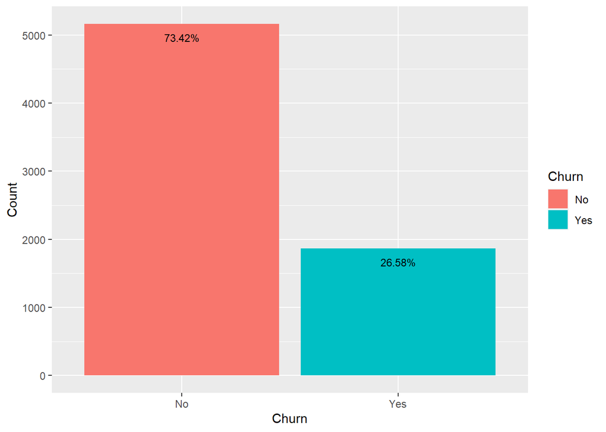

```r
ggplot(churn, aes(x=Churn,fill=Churn))+ geom_bar() + geom_text(aes(y = ..count..-200, label = paste0(round(prop.table(..count..),4) * 100, '%')), stat = 'count',
position = position_dodge(.1), size = 3)+ ylab("Count")
```

#From the graph we see there are 26.58% customers that churn

#Tenure

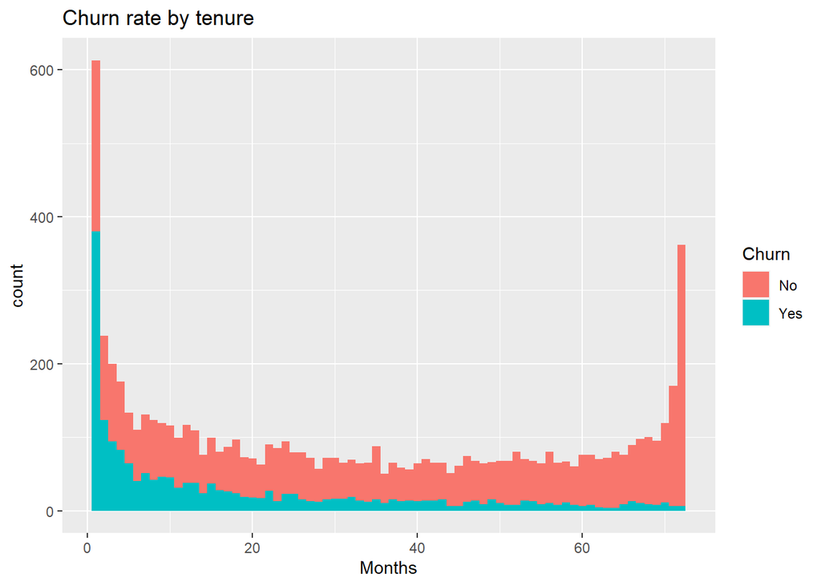

```r
ggplot(churn, aes(x = tenure, fill = Churn)) +
 geom_histogram(binwidth = 1) +
 labs(x = "Months",
      title = "Churn rate by tenure")
```

#From the graph we see that Customers are likely to churn after 1 month.

#Gender , Senior Citizen , Partner , Dependents

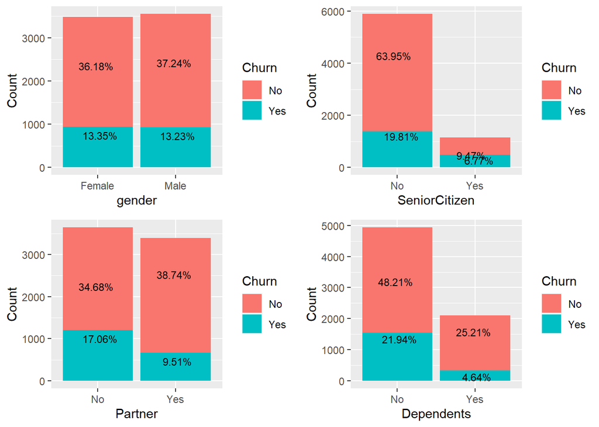

```r
a<-ggplot(churn, aes(x=gender,fill=Churn))+ geom_bar() + geom_text(aes(y = ..count.. -200, label = paste0(round(prop.table(..count..),4) * 100, '%')), stat = 'count',
 position = position_dodge(.1),  size = 3)+ ylab("Count")


b<-ggplot(churn, aes(x=SeniorCitizen,fill=Churn))+ geom_bar() + geom_text(aes(y = ..count.. -200, label = paste0(round(prop.table(..count..),4) * 100, '%')),
 stat = 'count', position = position_dodge(0.2), size = 3)+ ylab("Count")



c<-ggplot(churn, aes(x=Partner,fill=Churn))+ geom_bar() + geom_text(aes(y = ..count.. -200, label = paste0(round(prop.table(..count..),4) * 100, '%')), stat = 'count',
position = position_dodge(.1), size = 3)+ ylab("Count")


d<-ggplot(churn, aes(x=Dependents,fill=Churn))+ geom_bar() + geom_text(aes(y = ..count.. -200,label = paste0(round(prop.table(..count..),4) * 100, '%')),
stat = 'count',position = position_dodge(.1), size = 3) + ylab("Count")

grid.arrange(a,b,c,d,ncol=2)
```

#Based on Service

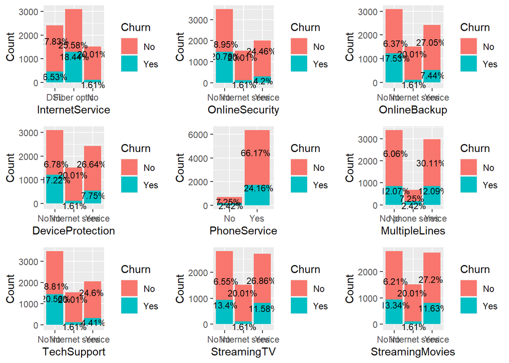

```r
grid.arrange(ggplot(churn, aes(x=InternetService,fill=Churn))+ geom_bar() + geom_text(aes(y = ..count.. -200,label = paste0(round(prop.table(..count..),4) * 100, '%')), stat = 'count', position = position_dodge(.1),size = 3)+ ylab("Count"),

             ggplot(churn, aes(x=OnlineSecurity,fill=Churn))+ geom_bar() + geom_text(aes(y = ..count.. -200,label = paste0(round(prop.table(..count..),4) * 100, '%')),stat = 'count',position = position_dodge(0.2),size = 3)+ ylab("Count"),

             ggplot(churn, aes(x=OnlineBackup,fill=Churn))+ geom_bar() + geom_text(aes(y = ..count.. -200,label = paste0(round(prop.table(..count..),4) * 100, '%')),stat = 'count',position = position_dodge(0.2),size = 3)+ ylab("Count"),

             ggplot(churn, aes(x=DeviceProtection,fill=Churn))+ geom_bar() + geom_text(aes(y = ..count.. -200,label = paste0(round(prop.table(..count..),4) * 100, '%')),stat = 'count',position = position_dodge(0.2),size = 3)+ ylab("Count"),

             ggplot(churn, aes(x=PhoneService,fill=Churn))+ geom_bar() + geom_text(aes(y = ..count.. -200,label = paste0(round(prop.table(..count..),4) * 100, '%')),stat = 'count',position = position_dodge(0.2),size = 3)+ ylab("Count"),

             ggplot(churn, aes(x=MultipleLines,fill=Churn))+ geom_bar() + geom_text(aes(y = ..count.. -200,label = paste0(round(prop.table(..count..),4) * 100, '%')), stat = 'count',position = position_dodge(0.2), size = 3)+ ylab("Count"),

             ggplot(churn, aes(x=TechSupport,fill=Churn))+ geom_bar() + geom_text(aes(y = ..count.. -200,label = paste0(round(prop.table(..count..),4) * 100, '%')), stat = 'count', position = position_dodge(0.2),size = 3)+ ylab("Count"),

             ggplot(churn, aes(x=StreamingTV,fill=Churn))+ geom_bar() + geom_text(aes(y = ..count.. -200,label = paste0(round(prop.table(..count..),4) * 100, '%')),stat = 'count',position = position_dodge(0.2), size = 3)+ ylab("Count"),

             ggplot(churn, aes(x=StreamingMovies,fill=Churn))+ geom_bar() + geom_text(aes(y = ..count.. -200,label = paste0(round(prop.table(..count..),4) * 100, '%')), stat = 'count',position = position_dodge(0.2),size = 3)+ ylab("Count"))
```

#From above plots #Customer who use fiber optic in internet service are more likely to churn #Customer who don’t use online security, online backup, device protection, streaming TV, and tech support are more likely to churn

#Statistical tests

```r
str(churn)
```

```
## 'data.frame':    7032 obs. of  20 variables:
##  $ gender          : Factor w/ 2 levels "Female","Male": 1 2 2 2 1 1 2 1 1 2 ...
##  $ SeniorCitizen   : Factor w/ 2 levels "No","Yes": 1 1 1 1 1 1 1 1 1 1 ...
##  $ Partner         : Factor w/ 2 levels "No","Yes": 2 1 1 1 1 1 1 1 2 1 ...
##  $ Dependents      : Factor w/ 2 levels "No","Yes": 1 1 1 1 1 1 2 1 1 2 ...
##  $ tenure          : int  1 34 2 45 2 8 22 10 28 62 ...
##  $ PhoneService    : Factor w/ 2 levels "No","Yes": 1 2 2 1 2 2 2 1 2 2 ...
##  $ MultipleLines   : Factor w/ 3 levels "No","No phone service",..: 2 1 1 2 1 3 3 2 3 1 ...
##  $ InternetService : Factor w/ 3 levels "DSL","Fiber optic",..: 1 1 1 1 2 2 2 1 2 1 ...
##  $ OnlineSecurity  : Factor w/ 3 levels "No","No internet service",..: 1 3 3 3 1 1 1 3 1 3 ...
##  $ OnlineBackup    : Factor w/ 3 levels "No","No internet service",..: 3 1 3 1 1 1 3 1 1 3 ...
##  $ DeviceProtection: Factor w/ 3 levels "No","No internet service",..: 1 3 1 3 1 3 1 1 3 1 ...
##  $ TechSupport     : Factor w/ 3 levels "No","No internet service",..: 1 1 1 3 1 1 1 1 3 1 ...
##  $ StreamingTV     : Factor w/ 3 levels "No","No internet service",..: 1 1 1 1 1 3 3 1 3 1 ...
##  $ StreamingMovies : Factor w/ 3 levels "No","No internet service",..: 1 1 1 1 1 3 1 1 3 1 ...
##  $ Contract        : Factor w/ 3 levels "Month-to-month",..: 1 2 1 2 1 1 1 1 1 2 ...
##  $ PaperlessBilling: Factor w/ 2 levels "No","Yes": 2 1 2 1 2 2 2 1 2 1 ...
##  $ PaymentMethod   : Factor w/ 4 levels "Bank transfer (automatic)",..: 3 4 4 1 3 3 2 4 3 1 ...
##  $ MonthlyCharges  : num  29.9 57 53.9 42.3 70.7 ...
##  $ TotalCharges    : num  29.9 1889.5 108.2 1840.8 151.7 ...
##  $ Churn           : Factor w/ 2 levels "No","Yes": 1 1 2 1 2 2 1 1 2 1 ...
```

```r
chisq.test(churn$Churn, churn$gender)
```

```
##
##  Pearson's Chi-squared test with Yates' continuity correction
##
## data:  churn$Churn and churn$gender
## X-squared = 0.47545, df = 1, p-value = 0.4905
```

```r
chisq.test(churn$Churn, churn$SeniorCitizen)
```

```
##
##  Pearson's Chi-squared test with Yates' continuity correction
##
## data:  churn$Churn and churn$SeniorCitizen
## X-squared = 158.44, df = 1, p-value < 2.2e-16
```

```r
chisq.test(churn$Churn, churn$Partner)
```

```
##
##  Pearson's Chi-squared test with Yates' continuity correction
##
## data:  churn$Churn and churn$Partner
## X-squared = 157.5, df = 1, p-value < 2.2e-16
```

```r
chisq.test(churn$Churn, churn$Dependents)
```

```
##
##  Pearson's Chi-squared test with Yates' continuity correction
##
## data:  churn$Churn and churn$Dependents
## X-squared = 186.32, df = 1, p-value < 2.2e-16
```

```r
chisq.test(churn$Churn, churn$PhoneService)
```

```
##
##  Pearson's Chi-squared test with Yates' continuity correction
##
## data:  churn$Churn and churn$PhoneService
## X-squared = 0.87373, df = 1, p-value = 0.3499
```

```r
chisq.test(churn$Churn, churn$MultipleLines)
```

```
##
##  Pearson's Chi-squared test
##
## data:  churn$Churn and churn$MultipleLines
## X-squared = 11.272, df = 2, p-value = 0.003568
```

```r
chisq.test(churn$Churn, churn$InternetService)
```

```
##
##  Pearson's Chi-squared test
##
## data:  churn$Churn and churn$InternetService
## X-squared = 728.7, df = 2, p-value < 2.2e-16
```

```r
chisq.test(churn$Churn, churn$OnlineSecurity)
```

```
##
##  Pearson's Chi-squared test
##
## data:  churn$Churn and churn$OnlineSecurity
## X-squared = 846.68, df = 2, p-value < 2.2e-16
```

```r
chisq.test(churn$Churn, churn$OnlineBackup)
```

```
##
##  Pearson's Chi-squared test
##
## data:  churn$Churn and churn$OnlineBackup
## X-squared = 599.18, df = 2, p-value < 2.2e-16
```

```r
chisq.test(churn$Churn, churn$DeviceProtection)
```

```
##
##  Pearson's Chi-squared test
##
## data:  churn$Churn and churn$DeviceProtection
## X-squared = 555.88, df = 2, p-value < 2.2e-16
```

```r
chisq.test(churn$Churn, churn$TechSupport)
```

```
##
##  Pearson's Chi-squared test
##
## data:  churn$Churn and churn$TechSupport
## X-squared = 824.93, df = 2, p-value < 2.2e-16
```

```r
chisq.test(churn$Churn, churn$StreamingTV)
```

```
##
##  Pearson's Chi-squared test
##
## data:  churn$Churn and churn$StreamingTV
## X-squared = 372.46, df = 2, p-value < 2.2e-16
```

```r
chisq.test(churn$Churn, churn$StreamingMovies)
```

```
##
##  Pearson's Chi-squared test
##
## data:  churn$Churn and churn$StreamingMovies
## X-squared = 374.27, df = 2, p-value < 2.2e-16
```

```r
chisq.test(churn$Churn, churn$PaperlessBilling)
```

```
##
##  Pearson's Chi-squared test with Yates' continuity correction
##
## data:  churn$Churn and churn$PaperlessBilling
## X-squared = 256.87, df = 1, p-value < 2.2e-16
```

```r
chisq.test(churn$Churn, churn$PaymentMethod )
```

```
##
##  Pearson's Chi-squared test
##
## data:  churn$Churn and churn$PaymentMethod
## X-squared = 645.43, df = 3, p-value < 2.2e-16
```

```r
chisq.test(churn$Churn, churn$Contract)
```

```
##
##  Pearson's Chi-squared test
##
## data:  churn$Churn and churn$Contract
## X-squared = 1179.5, df = 2, p-value < 2.2e-16
```

```r
t.test(tenure~Churn,data=churn)
```

```
##
##  Welch Two Sample t-test
##
## data:  tenure by Churn
## t = 34.972, df = 4045.5, p-value < 2.2e-16
## alternative hypothesis: true difference in means is not equal to 0
## 95 percent confidence interval:
##  18.56811 20.77364
## sample estimates:
##  mean in group No mean in group Yes
##          37.65001          17.97913
```

```r
t.test(TotalCharges~Churn,data=churn)
```

```
##
##  Welch Two Sample t-test
##
## data:  TotalCharges by Churn
## t = 18.801, df = 4042.9, p-value < 2.2e-16
## alternative hypothesis: true difference in means is not equal to 0
## 95 percent confidence interval:
##   916.8121 1130.2840
## sample estimates:
##  mean in group No mean in group Yes
##          2555.344          1531.796
```

```r
t.test(MonthlyCharges~Churn,data=churn)
```

```
##
##  Welch Two Sample t-test
##
## data:  MonthlyCharges by Churn
## t = -18.341, df = 4139.7, p-value < 2.2e-16
## alternative hypothesis: true difference in means is not equal to 0
## 95 percent confidence interval:
##  -14.53786 -11.72998
## sample estimates:
##  mean in group No mean in group Yes
##          61.30741          74.44133
```

##Model building

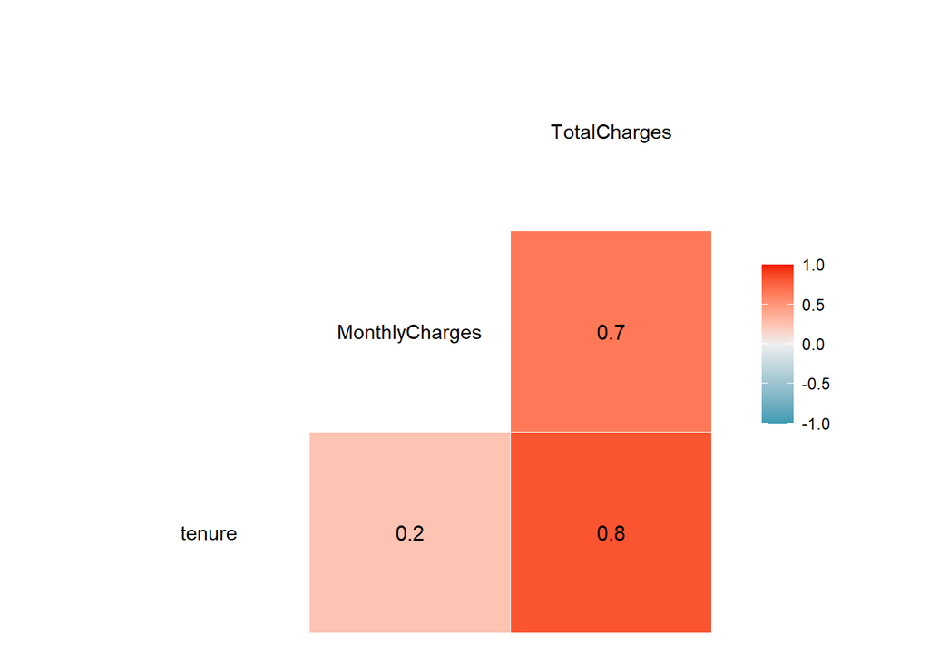

```r
library(GGally)
ggcorr(churn, label = T)
```

#Since Total charges has strong correlation with tenure and MonthlyCharges, It can be taken out

```r
churn <- churn %>% select(-TotalCharges)

library(caret)
split_train_test <- createDataPartition(churn$Churn,p=0.7,list=FALSE)
set.seed(1234)
dtrain<- churn[split_train_test,]
dtest<- churn[-split_train_test,]


mod <- glm(Churn ~., data = dtrain,
              family=binomial(link='logit'))
summary(mod)
```

```
##
## Call:
## glm(formula = Churn ~ ., family = binomial(link = "logit"), data = dtrain)
##
## Deviance Residuals:
##     Min       1Q   Median       3Q      Max
## -1.9594  -0.6809  -0.2953   0.7066   3.1545
##
## Coefficients: (7 not defined because of singularities)
##                                        Estimate Std. Error z value Pr(>|z|)
## (Intercept)                           4.619e-02  9.607e-01   0.048 0.961650
## genderMale                           -1.212e-07  7.734e-02   0.000 0.999999
## SeniorCitizenYes                      2.575e-01  1.019e-01   2.527 0.011499 *
## PartnerYes                            6.478e-03  9.229e-02   0.070 0.944035
## DependentsYes                        -9.083e-02  1.048e-01  -0.867 0.386115
## tenure                               -3.503e-02  2.846e-03 -12.310  < 2e-16 ***
## PhoneServiceYes                      -2.112e-01  7.725e-01  -0.273 0.784566
## MultipleLinesNo phone service                NA         NA      NA       NA
## MultipleLinesYes                      3.048e-01  2.102e-01   1.450 0.147004
## InternetServiceFiber optic            1.141e+00  9.528e-01   1.198 0.230948
## InternetServiceNo                    -1.050e+00  9.594e-01  -1.095 0.273685
## OnlineSecurityNo internet service            NA         NA      NA       NA
## OnlineSecurityYes                    -2.477e-01  2.139e-01  -1.158 0.246844
## OnlineBackupNo internet service              NA         NA      NA       NA
## OnlineBackupYes                      -2.446e-02  2.099e-01  -0.117 0.907243
## DeviceProtectionNo internet service          NA         NA      NA       NA
## DeviceProtectionYes                   1.824e-01  2.110e-01   0.864 0.387458
## TechSupportNo internet service               NA         NA      NA       NA
## TechSupportYes                       -3.046e-01  2.158e-01  -1.411 0.158229
## StreamingTVNo internet service               NA         NA      NA       NA
## StreamingTVYes                        3.916e-01  3.898e-01   1.005 0.315043
## StreamingMoviesNo internet service           NA         NA      NA       NA
## StreamingMoviesYes                    4.323e-01  3.868e-01   1.118 0.263746
## ContractOne year                     -7.049e-01  1.264e-01  -5.577 2.45e-08 ***
## ContractTwo year                     -1.417e+00  2.151e-01  -6.588 4.46e-11 ***
## PaperlessBillingYes                   3.315e-01  8.924e-02   3.715 0.000203 ***
## PaymentMethodCredit card (automatic) -5.358e-02  1.375e-01  -0.390 0.696807
## PaymentMethodElectronic check         3.659e-01  1.155e-01   3.169 0.001528 **
## PaymentMethodMailed check            -1.972e-02  1.373e-01  -0.144 0.885758
## MonthlyCharges                       -1.259e-02  3.783e-02  -0.333 0.739294
## ---
## Signif. codes:  0 '***' 0.001 '**' 0.01 '*' 0.05 '.' 0.1 ' ' 1
##
## (Dispersion parameter for binomial family taken to be 1)
##
##     Null deviance: 5702.8  on 4923  degrees of freedom
## Residual deviance: 4117.7  on 4901  degrees of freedom
## AIC: 4163.7
##
## Number of Fisher Scoring iterations: 6
```

#Here we can see that 7 coeffiencients are not defined and throws NA because the model is recognizing that two or more of the predictors are identical, or perfectly predicted by the combination of the other two predictors. This means that we cannot include all three terms in your model.

#changing “No phone service” to “No” for column “MultipleLines”

```r
library(plyr)
```

```r
churn$MultipleLines <- as.factor(mapvalues(churn$MultipleLines,
                                           from=c("No phone service"),
                                           to=c("No")))
```

#changing “No internet service” to “No” for column “OnlineSecurity”

```r
churn$OnlineSecurity <- as.factor(mapvalues(churn$OnlineSecurity,
                                           from=c("No internet service"),
                                           to=c("No")))
```

#changing “No internet service” to “No” for column “OnlineBackup”

```r
churn$OnlineBackup <- as.factor(mapvalues(churn$OnlineBackup,
                                            from=c("No internet service"),
                                            to=c("No")))
```

#changing “No internet service” to “No” for column “DeviceProtection”

```r
churn$DeviceProtection <- as.factor(mapvalues(churn$DeviceProtection,
                                          from=c("No internet service"),
                                          to=c("No")))
```

#changing “No internet service” to “No” for column “TechSupport”

```r
churn$TechSupport <- as.factor(mapvalues(churn$TechSupport,
                                              from=c("No internet service"),
                                              to=c("No")))
```

#changing “No internet service” to “No” for column “StreamingTV”

```r
churn$StreamingTV <- as.factor(mapvalues(churn$StreamingTV,
                                         from=c("No internet service"),
                                         to=c("No")))
```

#changing “No internet service” to “No” for column “StreamingMovies”

```r
churn$StreamingMovies <- as.factor(mapvalues(churn$StreamingMovies,
                                         from=c("No internet service"),
                                         to=c("No")))
```

#Building the model again

```r
split_train_test <- createDataPartition(churn$Churn,p=0.7,list=FALSE)
set.seed(1234)
dtrain<- churn[split_train_test,]
dtest<- churn[-split_train_test,]


mod <- glm(Churn ~., data = dtrain,
           family=binomial(link='logit'))
summary(mod)
```

```
##
## Call:
## glm(formula = Churn ~ ., family = binomial(link = "logit"), data = dtrain)
##
## Deviance Residuals:
##     Min       1Q   Median       3Q      Max
## -2.0185  -0.6680  -0.2970   0.6912   3.1793
##
## Coefficients:
##                                       Estimate Std. Error z value Pr(>|z|)
## (Intercept)                           0.842036   0.977188   0.862 0.388857
## genderMale                           -0.035908   0.077835  -0.461 0.644560
## SeniorCitizenYes                      0.308060   0.102459   3.007 0.002641 **
## PartnerYes                            0.002509   0.092740   0.027 0.978416
## DependentsYes                        -0.114567   0.106982  -1.071 0.284217
## tenure                               -0.035396   0.002838 -12.470  < 2e-16 ***
## PhoneServiceYes                       0.434824   0.784626   0.554 0.579456
## MultipleLinesYes                      0.506957   0.214150   2.367 0.017918 *
## InternetServiceFiber optic            2.049298   0.964914   2.124 0.033686 *
## InternetServiceNo                    -1.898790   0.976424  -1.945 0.051819 .
## OnlineSecurityYes                    -0.105357   0.214014  -0.492 0.622513
## OnlineBackupYes                       0.122858   0.211276   0.582 0.560901
## DeviceProtectionYes                   0.263354   0.211704   1.244 0.213510
## TechSupportYes                       -0.140957   0.219045  -0.644 0.519894
## StreamingTVYes                        0.594218   0.393805   1.509 0.131321
## StreamingMoviesYes                    0.863346   0.395310   2.184 0.028964 *
## ContractOne year                     -0.628359   0.127402  -4.932 8.14e-07 ***
## ContractTwo year                     -1.307140   0.211299  -6.186 6.16e-10 ***
## PaperlessBillingYes                   0.328010   0.089086   3.682 0.000231 ***
## PaymentMethodCredit card (automatic) -0.080909   0.136990  -0.591 0.554777
## PaymentMethodElectronic check         0.448867   0.113850   3.943 8.06e-05 ***
## PaymentMethodMailed check             0.086523   0.136515   0.634 0.526212
## MonthlyCharges                       -0.045715   0.038371  -1.191 0.233496
## ---
## Signif. codes:  0 '***' 0.001 '**' 0.01 '*' 0.05 '.' 0.1 ' ' 1
##
## (Dispersion parameter for binomial family taken to be 1)
##
##     Null deviance: 5702.8  on 4923  degrees of freedom
## Residual deviance: 4076.1  on 4901  degrees of freedom
## AIC: 4122.1
##
## Number of Fisher Scoring iterations: 6
```

#Confusion matrix

```r
lr_prob1 <- predict(mod, dtest, type="response")
lr_pred1 <- ifelse(lr_prob1 > 0.5,"Yes","No")
table(Predicted = lr_pred1, Actual = dtest$Churn)
```

```
##          Actual
## Predicted   No  Yes
##       No  1382  251
##       Yes  166  309
```

the false negative rate 251/(251+309)

false positive rate 166 / (166+1382)

False Negative rate is much larger

```r
lr_tab2 <- table(Predicted = lr_pred1, Actual = dtest$Churn)
lr_acc <- sum(diag(lr_tab2))/sum(lr_tab2)
lr_acc
```

```
## [1] 0.8021822
```

#Lasso linear regression

```r
set.seed(1)

lasso <- train(Churn ~ ., data = dtrain, method = "glmnet",metric = "ROC",na.action=na.pass, preProc="knnImpute", trControl = trainControl("cv", number = 10,sampling = "smote",summaryFunction = twoClassSummary,classProbs = TRUE),tuneGrid = expand.grid(alpha = 1, lambda = 10^seq(-3, 3, length = 100)))
lasso
```

```
## glmnet
##
## 4924 samples
##   18 predictor
##    2 classes: 'No', 'Yes'
##
## Pre-processing: nearest neighbor imputation (22), centered (22), scaled (22)
## Resampling: Cross-Validated (10 fold)
## Summary of sample sizes: 4433, 4432, 4432, 4431, 4431, 4432, ...
## Addtional sampling using SMOTE prior to pre-processing
##
## Resampling results across tuning parameters:
##
##   lambda        ROC        Sens       Spec
##   1.000000e-03  0.8428946  0.7421871  0.7861010
##   1.149757e-03  0.8429566  0.7419109  0.7868644
##   1.321941e-03  0.8429102  0.7416347  0.7868644
##   1.519911e-03  0.8429883  0.7416347  0.7868644
##   1.747528e-03  0.8429459  0.7410822  0.7891544
##   2.009233e-03  0.8429714  0.7408052  0.7883852
##   2.310130e-03  0.8430784  0.7408044  0.7883852
##   2.656088e-03  0.8431134  0.7405266  0.7876218
##   3.053856e-03  0.8431738  0.7394209  0.7876218
##   3.511192e-03  0.8432457  0.7383144  0.7868585
##   4.037017e-03  0.8432734  0.7377604  0.7883852
##   4.641589e-03  0.8433493  0.7396971  0.7868585
##   5.336699e-03  0.8433379  0.7399749  0.7876218
##   6.135907e-03  0.8434181  0.7396979  0.7899237
##   7.054802e-03  0.8433508  0.7391446  0.7899237
##   8.111308e-03  0.8432587  0.7385937  0.7906870
##   9.326033e-03  0.8430180  0.7388699  0.7899295
##   1.072267e-02  0.8428712  0.7383159  0.7906929
##   1.232847e-02  0.8426724  0.7380381  0.7891720
##   1.417474e-02  0.8422718  0.7385906  0.7891720
##   1.629751e-02  0.8420288  0.7369332  0.7899354
##   1.873817e-02  0.8418822  0.7374857  0.7884028
##   2.154435e-02  0.8411825  0.7366546  0.7876277
##   2.477076e-02  0.8404173  0.7341661  0.7860893
##   2.848036e-02  0.8395094  0.7327819  0.7860893
##   3.274549e-02  0.8382520  0.7325056  0.7906870
```

[output cut: 63 more lines]

```
##   2.477076e+02  0.5000000  1.0000000  0.0000000
##   2.848036e+02  0.5000000  1.0000000  0.0000000
##   3.274549e+02  0.5000000  1.0000000  0.0000000
##   3.764936e+02  0.5000000  1.0000000  0.0000000
##   4.328761e+02  0.5000000  1.0000000  0.0000000
##   4.977024e+02  0.5000000  1.0000000  0.0000000
##   5.722368e+02  0.5000000  1.0000000  0.0000000
##   6.579332e+02  0.5000000  1.0000000  0.0000000
##   7.564633e+02  0.5000000  1.0000000  0.0000000
##   8.697490e+02  0.5000000  1.0000000  0.0000000
##   1.000000e+03  0.5000000  1.0000000  0.0000000
##
## Tuning parameter 'alpha' was held constant at a value of 1
## ROC was used to select the optimal model using the largest value.
## The final values used for the model were alpha = 1 and lambda = 0.006135907.
```

```r
coef(lasso$finalModel, lasso$bestTune$lambda)
```

```
## 23 x 1 sparse Matrix of class "dgCMatrix"
##                                               s1
## (Intercept)                          -0.10883066
## genderMale                            .
## SeniorCitizenYes                      0.11226004
## PartnerYes                           -0.00155569
## DependentsYes                        -0.05380739
## tenure                               -0.69705381
## PhoneServiceYes                      -0.07324413
## MultipleLinesYes                      0.05746401
## InternetServiceFiber optic            0.40407036
## InternetServiceNo                    -0.26233268
## OnlineSecurityYes                    -0.13658599
## OnlineBackupYes                      -0.01232673
## DeviceProtectionYes                   .
## TechSupportYes                       -0.13232505
## StreamingTVYes                        0.03475708
## StreamingMoviesYes                    0.16574449
## ContractOne year                     -0.25302684
## ContractTwo year                     -0.47590155
## PaperlessBillingYes                   0.13913810
## PaymentMethodCredit card (automatic) -0.02607105
## PaymentMethodElectronic check         0.24480854
## PaymentMethodMailed check             .
## MonthlyCharges                        .
```

```r
set.seed(1)

predictions <- predict(lasso,dtest)
acc_lasso <-mean(predictions==dtest$Churn)
acc_lasso
```

```
## [1] 0.7424099
```

#Ridge linear regression

```r
set.seed(1)

Ridge <- train(Churn~., data = dtrain, method = "glmnet",metric = "ROC",na.action=na.pass, preProc="knnImpute",trControl = trainControl("cv", number = 10,sampling = "smote",summaryFunction = twoClassSummary,classProbs = TRUE),tuneGrid = expand.grid(alpha = 0, lambda = 10^seq(-3, 3, length = 100)))


predictions <- predict(Ridge,dtest)
acc_ridge<-mean(predictions==dtest$Churn)
acc_ridge
```

```
## [1] 0.7457306
```

##Elastic net linear regression

```r
set.seed(1)

enet <- train(Churn~., data = dtrain, method = "glmnet",metric = "ROC",na.action=na.pass, preProc="knnImpute", trControl = trainControl("cv", number = 10,sampling = "smote",summaryFunction = twoClassSummary,classProbs = TRUE),tuneGrid = expand.grid(alpha = seq(0,1, length=10), lambda = 10^seq(-3, 3, length = 100)))

predictions <- predict(enet,dtest)
acc_enet<-mean(predictions==dtest$Churn)
acc_enet
```

```
## [1] 0.7457306
```

#rf

```r
set.seed(1)

rf <- train(Churn~., data = dtrain, method = "rf",metric = "ROC",na.action=na.pass, preProc="knnImpute", trControl = trainControl("cv", number = 10,sampling = "smote",summaryFunction = twoClassSummary,classProbs = TRUE),  importance=T)

predictions <- predict(rf,dtest)
acc_rf<-mean(predictions==dtest$Churn)
acc_rf
```

```
## [1] 0.790797
```

```r
varImp(rf)
```

```
## rf variable importance
##
##   only 20 most important variables shown (out of 22)
##
##                                      Importance
## tenure                                   100.00
## PaymentMethodElectronic check             60.38
## OnlineSecurityYes                         57.01
## TechSupportYes                            56.52
## PaperlessBillingYes                       55.22
## ContractOne year                          49.62
## MonthlyCharges                            43.58
## OnlineBackupYes                           41.16
## genderMale                                40.20
## PartnerYes                                37.77
## DependentsYes                             37.15
## SeniorCitizenYes                          35.69
## ContractTwo year                          34.18
## InternetServiceFiber optic                33.67
## PaymentMethodCredit card (automatic)      27.54
## DeviceProtectionYes                       26.99
## MultipleLinesYes                          24.22
## StreamingMoviesYes                        19.59
## StreamingTVYes                            17.09
## PaymentMethodMailed check                 10.75
```

#Gradient Boosted Tree

```r
set.seed(1)

gbm <- train(Churn~., data = dtrain, method = "gbm",metric = "ROC", trControl = trainControl("cv", number = 10,sampling = "smote",summaryFunction = twoClassSummary,classProbs = TRUE),  preProc="nzv")
predictions <- predict(gbm,dtest)
acc_gbm<-mean(predictions==dtest$Churn)
acc_gbm
```

```
## [1] 0.7955408
```

#SVM LINEAR

```r
set.seed(1)

svmLinear <- train(Churn~.,data = dtrain,method="svmLinear",metric = "ROC",na.action=na.pass, preProc="knnImpute",trControl = trainControl("cv", number = 10,sampling = "smote",summaryFunction = twoClassSummary,classProbs = TRUE))
predictions <- predict(svmLinear,dtest)
acc_svmLinear<-mean(predictions==dtest$Churn)
acc_svmLinear
```

```
## [1] 0.7063567
```

#C parameter adds a penalty for each misclassified data point. If c is small, the penalty for misclassified points is low so a decision boundary with a large margin is chosen at the expense of a greater number of misclassifications .

#SVM Radial

```r
set.seed(1)

svmRadial <- train(Churn~.,data = dtrain,method                    ="svmRadial",metric= "ROC",na.action=na.pass, preProc="knnImpute",trControl = trainControl("cv", number = 10,sampling = "smote",summaryFunction = twoClassSummary,classProbs = TRUE))
```

```
## line search fails -1.891795 0.07933958 1.337811e-05 -4.84721e-07 -2.387692e-08 1.661092e-09 -3.202333e-13
```

```r
predictions <- predict(svmRadial,dtest)
acc_svmRadial<-mean(predictions==dtest$Churn)
acc_svmRadial
```

```
## [1] 0.7694497
```

#KNN

```r
set.seed(1)

knnm <- train(Churn~.,data = dtrain,method ="knn",metric = "ROC",na.action=na.pass, preProc="knnImpute",trControl = trainControl("cv", number = 10,sampling = "smote",summaryFunction = twoClassSummary,classProbs = TRUE))
predictions <- predict(knnm,dtest)
acc_knn<-mean(predictions==dtest$Churn)
acc_knn
```

```
## [1] 0.6902277
```

#Neural Network

```r
library(caret)
intrain = createDataPartition(dtrain$Churn, p=0.9, list = FALSE)

value = dtrain[intrain,]
churn_validation = dtrain[-intrain,]
dtrain1 = value
```

```r
churn_train_numericals <- dtrain1[,-c(1:4,6,7,8,9,10,11,12,13,14,15,16,17,19)]
dummy <- dtrain1[,-c(5,18)]
churn_train_scale <- scale(churn_train_numericals)
scaled_train = cbind(churn_train_scale,dummy)

churn_test_numericals <- dtest[,-c(1:4,6,7,8,9,10,11,12,13,14,15,16,17,19)]
dummytest <- dtest[,-c(5,18)]
churn_test_scale <- scale(churn_test_numericals)
scaled_test = cbind(churn_test_scale,dummytest)

churn_val_numericals <- churn_validation[,-c(1:4,6,7,8,9,10,11,12,13,14,15,16,17,19)]
dummy_val <- churn_validation[,-c(5,18)]
churn_val_scale <- scale(churn_val_numericals)
scaled_val = cbind(churn_val_scale,dummy_val)

scaled_train_1 <- scaled_train[,-c(1:8,10,11:15,17,19)]
scaled_val_1 <- scaled_val[,-c(1:8,10,11:15,17,19)]
scaled_test_1 <- scaled_test[,-c(1:8,10,11:15,17,19)]

library(mltools)
library(data.table)
churn_train <- one_hot(data.table(scaled_train_1),dropUnusedLevels = FALSE)
churn_validation <- one_hot(data.table(scaled_val_1),dropUnusedLevels = FALSE)
churn_test <- one_hot(data.table(scaled_test_1),dropUnusedLevels = FALSE)

churn_train <- cbind(churn_train,scaled_train)
churn_train <- churn_train %>% select(-c(InternetService,Contract,PaymentMethod))

churn_test <- cbind(churn_test,scaled_test)
churn_test <- churn_test %>% select(-c(InternetService,Contract,PaymentMethod))

churn_val <- cbind(churn_validation,scaled_val)
churn_val <- churn_val %>% select(-c(InternetService,Contract,PaymentMethod))

churn_train$gender <- ifelse(churn_train$gender=="Male",1,0)
churn_train$SeniorCitizen <- ifelse(churn_train$SeniorCitizen=="Yes",1,0)
churn_train$Partner <- ifelse(churn_train$Partner=="Yes",1,0)
churn_train$Dependents <- ifelse(churn_train$Dependents=="Yes",1,0)
churn_train$PhoneService <- ifelse(churn_train$PhoneService=="Yes",1,0)
churn_train$MultipleLines <- ifelse(churn_train$MultipleLines=="Yes",1,0)
churn_train$OnlineSecurity <- ifelse(churn_train$OnlineSecurity=="Yes",1,0)
churn_train$OnlineBackup <- ifelse(churn_train$OnlineBackup=="Yes",1,0)
churn_train$DeviceProtection <- ifelse(churn_train$DeviceProtection=="Yes",1,0)
churn_train$TechSupport <- ifelse(churn_train$TechSupport=="Yes",1,0)
churn_train$StreamingTV <- ifelse(churn_train$StreamingTV=="Yes",1,0)
churn_train$StreamingMovies <- ifelse(churn_train$StreamingMovies=="Yes",1,0)
churn_train$PaperlessBilling <- ifelse(churn_train$PaperlessBilling=="Yes",1,0)
churn_train$Churn <- ifelse(churn_train$Churn=="Yes",1,0)

churn_test$gender <- ifelse(churn_test$gender=="Male",1,0)
churn_test$SeniorCitizen <- ifelse(churn_test$SeniorCitizen=="Yes",1,0)
churn_test$Partner <- ifelse(churn_test$Partner=="Yes",1,0)
churn_test$Dependents <- ifelse(churn_test$Dependents=="Yes",1,0)
churn_test$PhoneService <- ifelse(churn_test$PhoneService=="Yes",1,0)
churn_test$MultipleLines <- ifelse(churn_test$MultipleLines=="Yes",1,0)
churn_test$OnlineSecurity <- ifelse(churn_test$OnlineSecurity=="Yes",1,0)
churn_test$OnlineBackup <- ifelse(churn_test$OnlineBackup=="Yes",1,0)
churn_test$DeviceProtection <- ifelse(churn_test$DeviceProtection=="Yes",1,0)
churn_test$TechSupport <- ifelse(churn_test$TechSupport=="Yes",1,0)
churn_test$StreamingTV <- ifelse(churn_test$StreamingTV=="Yes",1,0)
churn_test$StreamingMovies <- ifelse(churn_test$StreamingMovies=="Yes",1,0)
churn_test$PaperlessBilling <- ifelse(churn_test$PaperlessBilling=="Yes",1,0)
churn_test$Churn <- ifelse(churn_test$Churn=="Yes",1,0)

churn_val$gender <- ifelse(churn_val$gender=="Male",1,0)
churn_val$SeniorCitizen <- ifelse(churn_val$SeniorCitizen=="Yes",1,0)
churn_val$Partner <- ifelse(churn_val$Partner=="Yes",1,0)
churn_val$Dependents <- ifelse(churn_val$Dependents=="Yes",1,0)
churn_val$PhoneService <- ifelse(churn_val$PhoneService=="Yes",1,0)
churn_val$MultipleLines <- ifelse(churn_val$MultipleLines=="Yes",1,0)
churn_val$OnlineSecurity <- ifelse(churn_val$OnlineSecurity=="Yes",1,0)
churn_val$OnlineBackup <- ifelse(churn_val$OnlineBackup=="Yes",1,0)
churn_val$DeviceProtection <- ifelse(churn_val$DeviceProtection=="Yes",1,0)
churn_val$TechSupport <- ifelse(churn_val$TechSupport=="Yes",1,0)
churn_val$StreamingTV <- ifelse(churn_val$StreamingTV=="Yes",1,0)
churn_val$StreamingMovies <- ifelse(churn_val$StreamingMovies=="Yes",1,0)
churn_val$PaperlessBilling <- ifelse(churn_val$PaperlessBilling=="Yes",1,0)
churn_val$Churn <- ifelse(churn_val$Churn=="Yes",1,0)


train = churn_train
test = churn_test
val = churn_val

churn_train_final = train[,-26]

churn_train_final_lab = train[,26]

churn_test_final = test[,-26]

churn_test_final_lab = test[,26]

churn_val_final = val[,-26]

churn_val_final_lab = val[,26]


churn_train_final = as.matrix(churn_train_final)

churn_train_final_lab = as.matrix(churn_train_final_lab)

churn_test_final = as.matrix(churn_test_final)

churn_test_final_lab = as.matrix(churn_test_final_lab)

churn_val_final = as.matrix(churn_val_final)

churn_val_final_lab = as.matrix(churn_val_final_lab)
```

```r
set.seed(1)

library(tfruns)
runs <- tuning_run("C:/Users/glane/Downloads/CHURN TUNE.R",
flags = list(
nodes1 = c(64, 128),
nodes2 = c(128,392),
learning_rate = c(0.01, 0.05, 0.001, 0.0001),
batch_size=c(100,200,500,1000),
epochs=c(30,50,100),
activation=c("relu","sigmoid","tanh")
),
sample = 0.02
)
```

```
## 576 total combinations of flags
```

```
## (sampled to 12 combinations)
```

```
## Training run 1/12 (flags = list(64, 128, 0.01, 100, 100, "relu"))
```

```
## Using run directory runs/2021-12-05T04-25-00Z
```

[output not shown]

```
##
## > model %>% fit(churn_train_final, churn_train_final_lab,
## +     epochs = FLAGS1$epochs, batch_size = FLAGS1$batch_size, validation_data = list(churn_ .... [TRUNCATED]
```

```
##
## Run completed: runs/2021-12-05T04-25-00Z
```

```
## Training run 2/12 (flags = list(64, 128, 1e-04, 1000, 50, "tanh"))
```

```
## Using run directory runs/2021-12-05T04-26-14Z
```

[output not shown]

```
##
## > model %>% fit(churn_train_final, churn_train_final_lab,
## +     epochs = FLAGS1$epochs, batch_size = FLAGS1$batch_size, validation_data = list(churn_ .... [TRUNCATED]
```

```
##
## Run completed: runs/2021-12-05T04-26-14Z
```

```
## Training run 3/12 (flags = list(64, 392, 0.05, 200, 50, "tanh"))
```

```
## Using run directory runs/2021-12-05T04-27-02Z
```

[output not shown]

```
##
## > model %>% fit(churn_train_final, churn_train_final_lab,
## +     epochs = FLAGS1$epochs, batch_size = FLAGS1$batch_size, validation_data = list(churn_ .... [TRUNCATED]
```

```
##
## Run completed: runs/2021-12-05T04-27-02Z
```

```
## Training run 4/12 (flags = list(64, 392, 0.001, 500, 50, "sigmoid"))
```

```
## Using run directory runs/2021-12-05T04-27-41Z
```

[output not shown]

```
##
## > model %>% fit(churn_train_final, churn_train_final_lab,
## +     epochs = FLAGS1$epochs, batch_size = FLAGS1$batch_size, validation_data = list(churn_ .... [TRUNCATED]
```

```
##
## Run completed: runs/2021-12-05T04-27-41Z
```

```
## Training run 5/12 (flags = list(128, 128, 1e-04, 100, 50, "sigmoid"))
```

```
## Using run directory runs/2021-12-05T04-28-19Z
```

[output not shown]

```
##
## > model %>% fit(churn_train_final, churn_train_final_lab,
## +     epochs = FLAGS1$epochs, batch_size = FLAGS1$batch_size, validation_data = list(churn_ .... [TRUNCATED]
```

```
##
## Run completed: runs/2021-12-05T04-28-19Z
```

```
## Training run 6/12 (flags = list(64, 392, 0.001, 1000, 100, "relu"))
```

```
## Using run directory runs/2021-12-05T04-29-04Z
```

[output not shown]

```
##
## > model %>% fit(churn_train_final, churn_train_final_lab,
## +     epochs = FLAGS1$epochs, batch_size = FLAGS1$batch_size, validation_data = list(churn_ .... [TRUNCATED]
```

```
##
## Run completed: runs/2021-12-05T04-29-04Z
```

```
## Training run 7/12 (flags = list(64, 392, 0.01, 1000, 50, "sigmoid"))
```

```
## Using run directory runs/2021-12-05T04-30-13Z
```

[output not shown]

```
##
## > model %>% fit(churn_train_final, churn_train_final_lab,
## +     epochs = FLAGS1$epochs, batch_size = FLAGS1$batch_size, validation_data = list(churn_ .... [TRUNCATED]
```

```
##
## Run completed: runs/2021-12-05T04-30-13Z
```

```
## Training run 8/12 (flags = list(64, 128, 0.05, 200, 50, "sigmoid"))
```

```
## Using run directory runs/2021-12-05T04-30-57Z
```

[output not shown]

```
##
## > model %>% fit(churn_train_final, churn_train_final_lab,
## +     epochs = FLAGS1$epochs, batch_size = FLAGS1$batch_size, validation_data = list(churn_ .... [TRUNCATED]
```

```
##
## Run completed: runs/2021-12-05T04-30-57Z
```

```
## Training run 9/12 (flags = list(128, 128, 1e-04, 500, 50, "tanh"))
```

```
## Using run directory runs/2021-12-05T04-31-44Z
```

[output not shown]

```
##
## > model %>% fit(churn_train_final, churn_train_final_lab,
## +     epochs = FLAGS1$epochs, batch_size = FLAGS1$batch_size, validation_data = list(churn_ .... [TRUNCATED]
```

```
##
## Run completed: runs/2021-12-05T04-31-44Z
```

```
## Training run 10/12 (flags = list(128, 128, 0.001, 100, 100, "sigmoid"))
```

```
## Using run directory runs/2021-12-05T04-32-21Z
```

[output not shown]

```
##
## > model %>% fit(churn_train_final, churn_train_final_lab,
## +     epochs = FLAGS1$epochs, batch_size = FLAGS1$batch_size, validation_data = list(churn_ .... [TRUNCATED]
```

```
##
## Run completed: runs/2021-12-05T04-32-21Z
```

```
## Training run 11/12 (flags = list(64, 128, 0.05, 500, 30, "relu"))
```

```
## Using run directory runs/2021-12-05T04-33-21Z
```

[output not shown]

```
##
## > model %>% fit(churn_train_final, churn_train_final_lab,
## +     epochs = FLAGS1$epochs, batch_size = FLAGS1$batch_size, validation_data = list(churn_ .... [TRUNCATED]
```

```
##
## Run completed: runs/2021-12-05T04-33-21Z
```

```
## Training run 12/12 (flags = list(64, 128, 0.001, 500, 50, "relu"))
```

```
## Using run directory runs/2021-12-05T04-33-52Z
```

[output not shown]

```
##
## > model %>% fit(churn_train_final, churn_train_final_lab,
## +     epochs = FLAGS1$epochs, batch_size = FLAGS1$batch_size, validation_data = list(churn_ .... [TRUNCATED]
```

```
##
## Run completed: runs/2021-12-05T04-33-52Z
```

```r
print(runs)
```

```
## Data frame: 12 x 26
##                      run_dir metric_loss metric_accuracy metric_val_loss
## 1  runs/2021-12-05T04-33-52Z      0.5862          0.7958          0.5843
## 2  runs/2021-12-05T04-33-21Z      0.5158          0.7674          0.4852
## 3  runs/2021-12-05T04-32-21Z      0.3860          0.8168          0.4316
## 4  runs/2021-12-05T04-31-44Z      2.2552          0.7719          2.3594
## 5  runs/2021-12-05T04-30-57Z      0.4155          0.8103          0.3989
## 6  runs/2021-12-05T04-30-13Z      0.4234          0.7956          0.4009
## 7  runs/2021-12-05T04-29-04Z      0.4871          0.7796          0.5295
## 8  runs/2021-12-05T04-28-19Z      0.4100          0.8078          0.4042
## 9  runs/2021-12-05T04-27-41Z      0.4186          0.8040          0.4009
## 10 runs/2021-12-05T04-27-02Z      4.1024          0.7340          4.0840
##    metric_val_accuracy
## 1               0.7658
## 2               0.7352
## 3               0.8086
## 4               0.8126
## 5               0.8248
## 6               0.8330
## 7               0.7373
## 8               0.8086
## 9               0.8248
## 10              0.7352
## # ... with 2 more rows
## # ... with 21 more columns:
## #   flag_nodes1, flag_batch_size, flag_activation, flag_learning_rate,
## #   flag_epochs, flag_nodes2, epochs, epochs_completed, metrics, model,
## #   loss_function, optimizer, learning_rate, script, start, end, completed,
## #   output, source_code, context, type
```

```r
view_run()
```

```
## starting httpd help server ...
```

```
##  done
```

```r
library(keras)
set.seed(1)

model =keras_model_sequential()

model %>%
  layer_dense(units = 64, activation = "sigmoid", input_shape = dim(churn_train_final)[2]) %>% layer_dropout(0.5) %>%
  layer_dense(units = 392, activation = "sigmoid") %>% layer_dropout(0.5) %>%
  layer_dense(units = 1,activation = "sigmoid")

model %>% compile(
 loss = 'binary_crossentropy',
 optimizer = optimizer_adam(lr=0.01),
 metrics = c('accuracy'))
model %>% fit(
  churn_train_final, churn_train_final_lab, epochs = 100
  , batch_size= 200,
   validation_data=list(churn_val_final, churn_val_final_lab))
```

```r
score <- model %>% evaluate(
  churn_test_final,churn_test_final_lab,
  batch_size = 200,
  verbose = 1
)

cat('Test accuracy', score[[2]], '\n')
```

```
## Test accuracy 0.7955408
```

##Compared the accuracy of logistic, lasso, ridge, elastic net, random forest, gbm,knn and neural networks models on the test data. Logistic regression has the best of the lot